# Food Inspection Failures Prediction in Chicago, IL

Yichao Jia & Anqi Li

Dec. 21, 2018

- 1. Introduction & Motivation
- 2. Data
  - 2.1. Overview
  - 2.2. Exploratory Analysis: Time & Temperature
  - 2.3. Spatial Relationships
  - 2.4. Comparison between establishments with and without fail records
- 3. Method
- 4. Results
  - 4.1. In-Sample Prediction Results & Validation on 2016 Outcomes
  - 4.2. Validation on Different Establishment Types
  - 4.3. Generalizability across space
- 5. Discussion & Limitation
- 6. Conclusion

# 1. Introduction & Motivation

Have you ever been poisoned by food? Many consumers may have the experience of getting sick after dining in a restaurant with a high score on establishment rating applications like Yelp. Some of them posted complaints and gave the restaurants the lowest rates, but their complaints soon got buried among all the compliments. Today we are already used to making our dining decisions based on the rating and review system, yet for most of the time we only talk about the taste, the price, or the service.

Every year, over 48,000,000 people in the U.S. fall ill from food poisoning, among whom approximately 128,000 need to take a visit to the hospital and 3,000 people even lose their lives. Although health departments are doing food inspection regularly, most of the data are just posted deep within the government website, and very few data are accessible and digestible by the public to prevent foodborne illness from happening again. However, food-bourn disease does matter to people and it is consumers¡¯ right to get informed of the inspection data and thus avoid risks of being poisoned.

Here we are making efforts to develop a new local search dining app in Chicago to provide eaters with food safety information. With the detailed Food Inspection dataset from Chicago Department of Public Health and selected predicting variables, we can build a model and produce prediction for which food establishments are likely to fail the inspection with violations. Based on the prediction results, we will able to assign each establishment a heath score and help eaters make more deliberative choice.

# 2. Data

## 2.1. Overview

First of all, let¡¯s take a look at the Food Inspection dataset from Chicago Department of Public Health. The dependent variable we use in the prediction is the Result of each inspection case. As the following plot shows, in the initial dataset, there are many different types of inspection results.

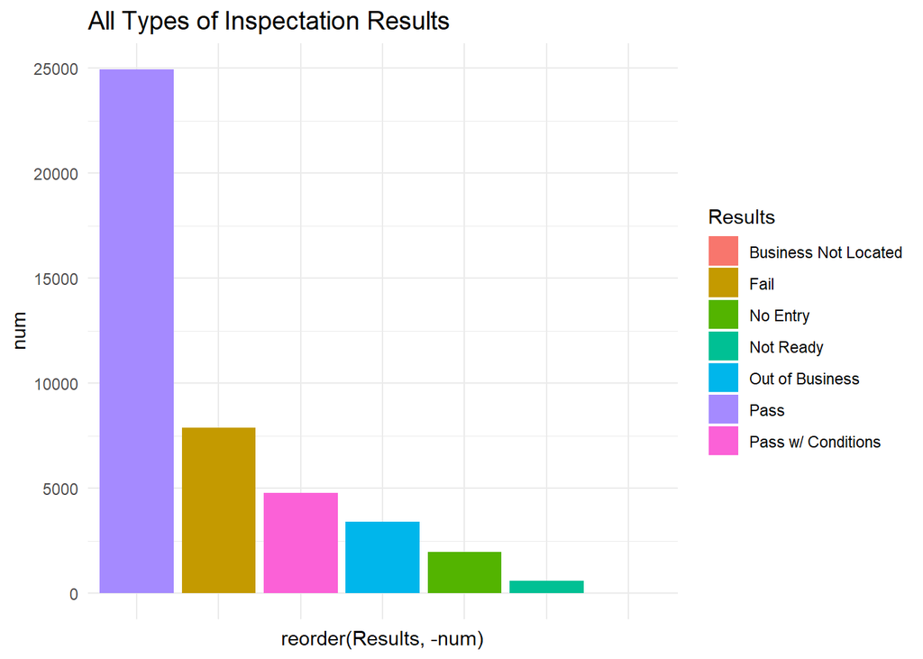

```r
inspectionRec <- read.socrata("https://data.cityofchicago.org/Health-Human-Services/Food-Inspections/4ijn-s7e5")



inspectionRec1516 <-
  inspectionRec %>%
  mutate(Data2 = ymd(Inspection.Date)) %>%
  filter(year(Data2) == "2015" | year(Data2) == "2016") %>%
  mutate(X = as.numeric(Longitude),
         Y = as.numeric(Latitude)) %>%
  na.omit

# Bar Chart of All types of Results
inspections_Results <-
  inspectionRec1516 %>%
  group_by(Results) %>%
  summarise(num = n())


ggplot(inspections_Results, aes(x=reorder(Results,-num), y=num, stat='identity',
                                fill = Results)) +
  geom_bar(stat="identity") +
  theme_minimal() +
  labs(title="All Types of Inspectation Results") +
  theme(plot.title = element_text(size = 14,colour = "black"),
        axis.text.x=element_blank(),
        axis.ticks.x=element_blank())
```

we can also generate a table to see the exact numbers.

```r
colnames(inspections_Results) <- c("result", "count")
inspections_Results %>%
  kable(align = "c") %>%
  kable_styling(bootstrap_options = c("striped", "hover", "condensed"),full_width = T)
```

| result | count |
| --- | --- |
| Business Not Located | 8 |
| Fail | 7871 |
| No Entry | 1953 |
| Not Ready | 585 |
| Out of Business | 3413 |
| Pass | 24954 |
| Pass w/ Conditions | 4779 |

Then we do some data cleaning to filter out only the results as pass, fail, and pass with conditions. We define Fail as factor 1 and Pass as factor 0. Here we count pass with conditions as fail because we want our prediction to capture as many violations as possible. Then let’s put the result into a new table.

```r
inspectionRec1516_valid <-
  inspectionRec1516 %>%
  filter(Results == "Pass" | Results == "Fail" | Results == "Pass w/ Conditions")

inspectionRec1516_valid$Res = 1
inspectionRec1516_valid$Res[which(inspectionRec1516_valid$Results =="Pass")] = 0

Results1516_valid <-
  inspectionRec1516_valid %>%
  group_by(Res) %>%
  summarise(num = n())

colnames(Results1516_valid) <- c("result", "count")
Results1516_valid %>%
  kable(align = "c") %>%
  kable_styling(bootstrap_options = c("striped", "hover", "condensed"),full_width = T)
```

| result | count |
| --- | --- |
| 0 | 24954 |
| 1 | 12650 |

Similar with Inspection Results, there are a number of food establishment types in the city, among which Restaurant ranks the first and Grocery the second.

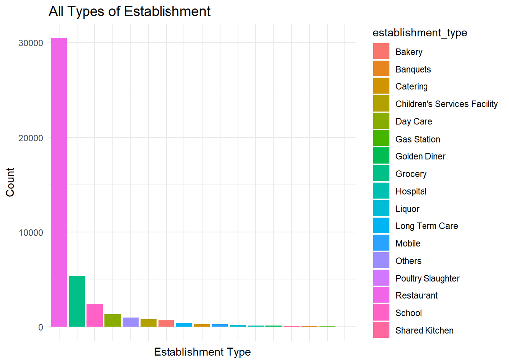

```r
establishment_type <-
  inspectionRec1516 %>%
  group_by(establishment_type) %>%
  summarise(num = n())

establishment_typeseq<-establishment_type %>%
  arrange(desc(num))

ggplot(establishment_typeseq, aes(x=reorder(establishment_type,-num), y=num, stat='identity',
                                  fill = establishment_type)) +
  geom_bar(aes(fill=establishment_type),position="dodge",stat="identity") +
  theme_minimal() +
  labs(title="All Types of Establishment",x='Establishment Type', y='Count') +
  theme(plot.title = element_text(size = 14,colour = "black"),
        axis.text.x=element_blank(),
        axis.ticks.x=element_blank())
```

Regarding independent variable, we collected and calculated two types of data that we viewed as relevant theoretically, including internal characteristics of establishments and external features of surrounding areas. The latter type can be further divided into demographic information of the block groups which the food establishments are located in and distance from establishments to relevant events or hotspots. All of the above data are available from Chicago Open Data Portal and 2015 American Community Survey 5-year Estimates.

A detailed variable list is provided below.

**Internal Chracteristics:**

Facility.Type: Type of Food Establishment  
Days_in_buis: Age of License till Inspection Date  
fail_Ever: Whether an Establishment Has Ever Failed an Inspection  
fail_rate: Percentage of Past Failed Inspections of an Establishment

**External Chracteristics:**

1)Block group demographic characteristics:

Household: Number of Household  
Pop_Den: Population Density  
MedAge: Median Age of Population  
PctUnder5: Percentage of Population Under 5 Years Old  
PctOver65: Percentage of Population OVer 65 Years Old  
PerCapInc: Per Capita Income  
Pov_R: Poverty Rate  
PctImmigra:Percentage of Immigrants  
Unemp_R: Unemployment Rate  
PctHighSch:Percentage of Population with High School Degree

2)Distance to relevant events / hotspots:

distParks: Distance to 2 Nearest Parks  
distLandmarks:Distance to 5 Nearest Landmarks  
distSani:Distance to 10 Nearest Sanitation Complaints  
distRodent:Distance to 10 Nearest Rodent Baiting Requests

3)Other Relavant Features:

MaxT: Maximum Temperature on Date of Inspection  
MinT: Minimum Temperature on Date of Inspection  
AverageT: Average Temperature on Date of Inspection  
Fail_10Neighbor: Count of Fails of 10 Nearest Neighboring Establishments

## 2.2. Exploratory Analysis: Time and Temperature

As we know food storage or processing issues are associated with season and temperature. So we extract the insepction date from the original dataset as one feature to see if there is a relationship between inspection results and the month in which the inspection took place. From the plot we can see that the number of failures drops in winter and increases in summer each year.

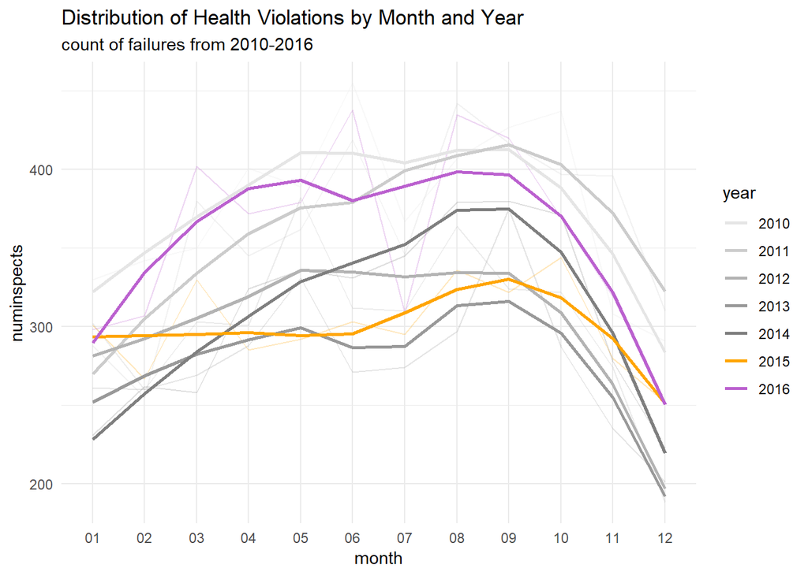

```r
# Time

inspections_time <- filter(inspectionRec, Inspection.Date < as.Date("2017-01-01"))

month_Inspections <-
  inspections_time %>%
  mutate(year=format(Inspection.Date,'%Y')) %>%
  mutate(month=format(Inspection.Date,'%m')) %>%
  mutate(week=as.numeric(format(Inspection.Date,"%W")))

inspections_Summary <-
  filter(month_Inspections, Results == "Fail") %>%
  group_by(month,year) %>%
  summarise(numinspects = n())

ggplot(inspections_Summary, aes(x=month,y=numinspects,group=year,color=year)) +
  geom_line(alpha=.25) +
  geom_smooth(se=F,method='loess',alpha=.35) +
  scale_colour_manual(values = c("GREY90","GREY80","GREY70","GREY60","GREY50","Orange", "#bb61cf")) +
  theme_minimal() +
  labs(title='Distribution of Health Violations by Month and Year',
       subtitle='count of failures from 2010-2016') +
  scale_y_continuous(labels=scales::comma)
```

We get the daily temperature of Chicago in 2015 and 2016 from NOAA Online weather data. Then join the data with our original dataset. We have daily average, minimum, and maximum temperature and after comparing the three respectively with the count of failures, we think maximum temperature has the strongest influence on inspection results.

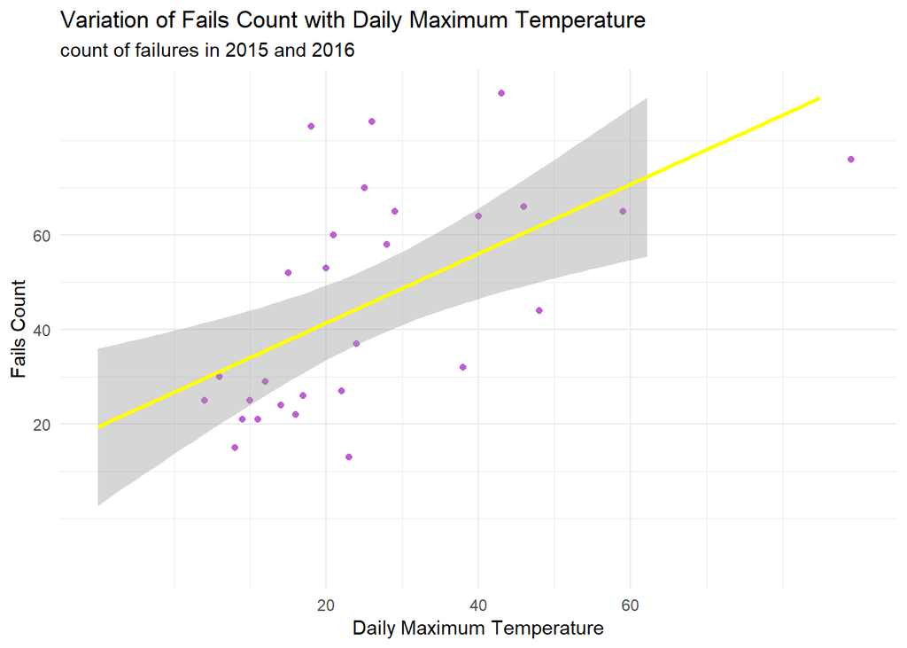

```r
# Temperature
Temperature <- read.csv("D:/18FALL/SPATIAL_ANALYTICS/FinalProject/temperature1516.csv") %>%
  mutate(Inspection.Date = as.Date(Date, format = "%Y-%m-%d"))

inspectionRec1516_valid$Inspection.Date <- as.Date(inspectionRec1516_valid$Inspection.Date)
inspectionRec1516_valid <- left_join(inspectionRec1516_valid, Temperature, by = "Inspection.Date")

ggplot(data = na.omit(inspectionRec1516_valid) %>%
         group_by(MaxT) %>%
         summarise(fails = sum(Res))) +
  geom_point(aes(x = MaxT, y=fails), colour = "#bb61cf") +
  geom_smooth(aes(x = MaxT, y=fails), colour = "yellow",
              method = lm, fullrange = TRUE) +
  scale_x_continuous(breaks = c(20, 40, 60),
                     limits = c(-10, 90)) +
  scale_y_continuous(breaks = c(20, 40, 60),
                     limits = c(-10, 90)) +
  labs(title='Variation of Fails Count with Daily Maximum Temperature',
       subtitle='count of failures in 2015 and 2016',x = "Daily Maximum Temperature", y = "Fails Count") +
  theme_minimal()
```

## 2.3. Spatial Relationships

First let’s see how the inspection results look like spatially.

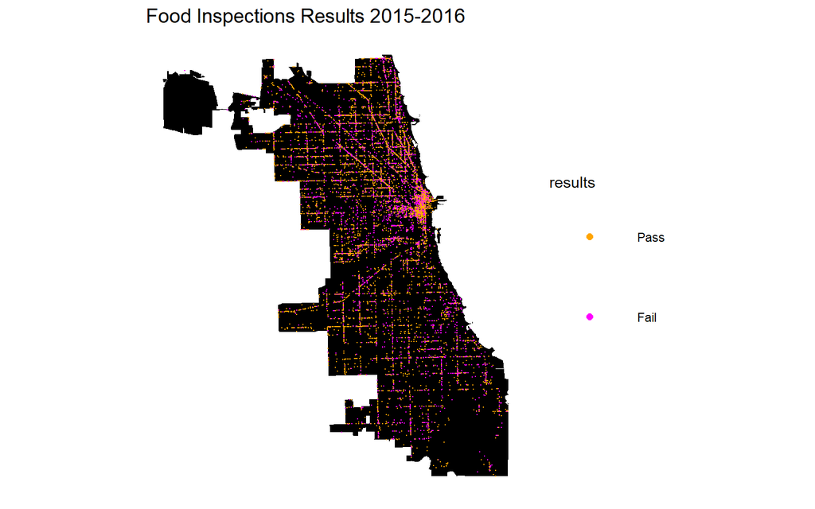

```r
citymap <- st_read("https://data.cityofchicago.org/api/geospatial/ewy2-6yfk?method=export&format=GeoJSON")

ggplot() +
  geom_sf(data=st_union(citymap), aes(), fill='black', colour=NA) +
  geom_point(data=inspectionRec1516_valid,
             aes(x=as.numeric(Longitude),y=as.numeric(Latitude), color=as.factor(inspectionRec1516_valid$Res)), size=0.1) +
  scale_color_manual(values=c("orange", "#ff00ff"), name = "results",
                     labels=c("Pass","Fail")) +
  labs(title = "Food Inspections Results 2015-2016") +
  mapTheme() +
  theme(legend.position = "right", legend.key.size = unit(2,"cm"),
        legend.key = element_rect(fill = "white", colour = "white"),plot.title = element_text(size = 14)) +
  guides(colour = guide_legend(override.aes = list(size=2)))
```

Let’s take a look at some spatial features such as the nearest neighbor distance to parks, landmarks, and 311 request complaints. Firstly parks and landmarks. Our guess is that when the food establishment is close to these assets, they tend to be more tourist-oriented and might be less careful with food safety issues. Here we calculated the distance to the nearest 2 parks and 5 landmarks of each inspection case.

```r
nn_function <- function(measureFrom,measureTo,k) {

  nn <-
    get.knnx(measureTo, measureFrom, k)$nn.dist

  output <-
    as.data.frame(nn) %>%
    rownames_to_column(var = "thisPoint") %>%
    gather(points, point_distance, V1:ncol(.)) %>%
    arrange(as.numeric(thisPoint)) %>%
    group_by(thisPoint) %>%
    summarise(pointDistance = mean(point_distance)) %>%
    arrange(as.numeric(thisPoint)) %>%
    dplyr::select(-thisPoint)

  return(output)
}

# distance - spatial features

parks <-
  st_read("D:/18FALL/SPATIAL_ANALYTICS/11/parks/park_centroid.shp")

parks.xy <-
  parks %>%
  cbind(.,st_coordinates(st_centroid(parks)))  %>%
  st_set_geometry(NULL) %>%
  dplyr::select(X,Y) %>%
  as.matrix()

inspect1516Valid.sf <-
  inspectionRec1516_valid %>%
  st_as_sf(coords = c("X", "Y"), crs = 4326, agr = "constant") %>%
  st_sf() %>%
  st_transform(st_crs(parks))

inspect1516Valid.xy <-
  inspect1516Valid.sf %>%
  cbind(.,st_coordinates(inspect1516Valid.sf))  %>%
  st_set_geometry(NULL) %>%
  dplyr::select(X,Y) %>%
  as.matrix()

distParks <- as.data.frame(nn_function(inspect1516Valid.xy,parks.xy,2))

inspect1516Valid.sf <-
  cbind(as.data.frame(inspect1516Valid.sf),distParks) %>%
  st_sf() %>%
  rename(Parkdis=pointDistance)

#landmarks

landmark <-
  read.socrata("https://data.cityofchicago.org/Historic-Preservation/Individual-Landmarks-Map/habu-n236") %>%
  dplyr::select(LATITUDE,LONGITUDE, Y = LATITUDE, X = LONGITUDE) %>%
  na.omit() %>%
  st_as_sf(coords = c("X", "Y"), crs = 4326, agr = "constant") %>%
  st_sf() %>%
  st_transform(st_crs(parks))

landmark.xy <-
  landmark %>%
  cbind(.,st_coordinates(st_centroid(landmark)))  %>%
  st_set_geometry(NULL) %>%
  dplyr::select(X,Y) %>%
  as.matrix()

distLandmarks <- as.data.frame(nn_function(inspect1516Valid.xy,landmark.xy,5))

inspect1516Valid.sf <-
  cbind(as.data.frame(inspect1516Valid.sf),distLandmarks) %>%
  st_sf() %>%
  rename(Landmarkdis=pointDistance)
```

Then let’s map them out.

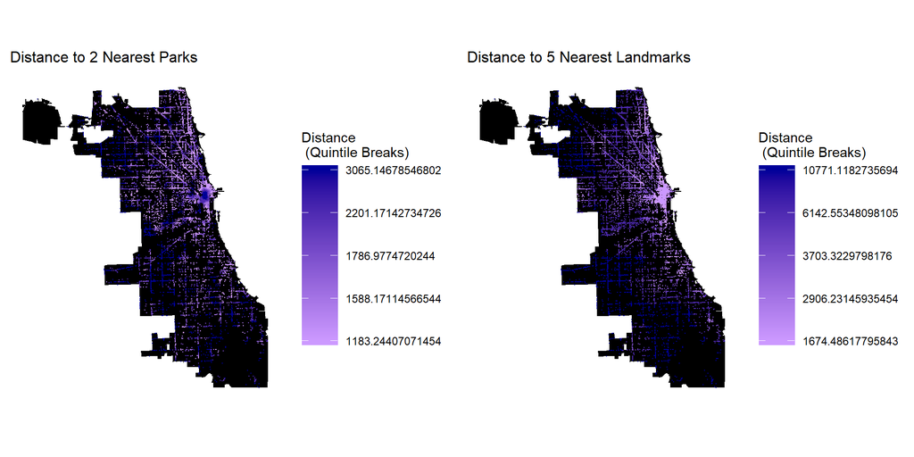

Distance to landmarks reminds us of the age of each food establishment. As we suspect that whether a neighborhood is featured by historic site or tourist attractions would effect the local food establishment’s performance in inspections, maybe the age of the establishment itself will also do. However, all we can find is a dataset of all business licenses in Chicago, which comes with the starting date of each business’s license term. So we try to join that with our dataset and calculate the age of the license for each food establishment being inspected.

```r
#Age of License till Inspection Date

LicenseData <- read.csv("D:/18FALL/SPATIAL_ANALYTICS/FinalProject/Business_Licenses.csv") %>%
  group_by(license_number) %>%
  summarise(TERM_START = min(as.Date(as.character(TERM_START), format = "%m/%d/%Y"))) %>%
  mutate(Days_in_busi=0)

inspect1516Valid.sf <-
  inspect1516Valid.sf %>%
  rename(license_number=License..)

inspect1516Valid.sf <- left_join(inspect1516Valid.sf, LicenseData, by = "license_number")

inspect1516Valid.sf$Days_in_busi <-
  as.Date(as.character(inspect1516Valid.sf$Inspection.Date), format = "%Y-%m-%d") -
  as.Date(as.character(inspect1516Valid.sf$TERM_START), format = "%Y-%m-%d")

inspect1516Valid.sf <-
  inspect1516Valid.sf %>%
  na.omit
```

We can also take a look at how the age of license (days in business) distribute sPatially. It seeems that there is no discernable pattern in its distribution.

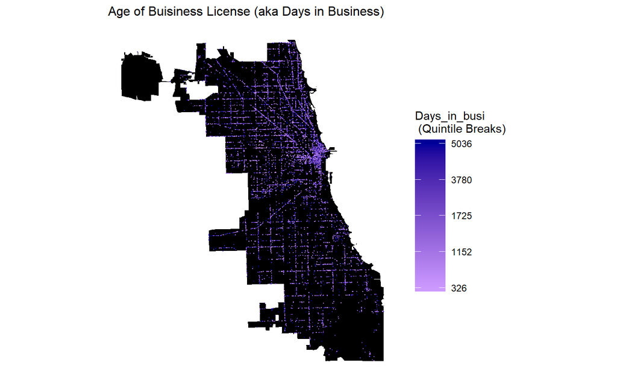

```r
ggplot() +
  geom_sf(data=st_union(citymap), aes(), fill='black', colour=NA) +
  geom_point(data=inspect1516Valid.sf,
             aes(x=as.numeric(Longitude),y=as.numeric(Latitude), color=ntile(inspect1516Valid.sf$Days_in_busi,5)), size=0.1) +
  scale_color_gradient(low = "#cc99ff", high = "#000099", space = "Lab",
                       labels=as.character(quantile(inspect1516Valid.sf$Days_in_busi,
                                                    c(.2,.4,.5,.7,.9),na.rm=T)),
                       name="Days_in_busi\n (Quintile Breaks)") +
  labs(title = "Age of Buisiness License (aka Days in Business)") +
  mapTheme() +
  theme(legend.position = "right", legend.key.size = unit(1,"cm"), legend.key = element_rect(fill = "white", colour = "white"),plot.title = element_text(size = 12))
```

Then we read in the shapefile containing the 2015 census data by block group and join the data with our inspection dataset.

```r
blockg_data <-
  st_read("D:/18FALL/SPATIAL_ANALYTICS/FinalProject/shapefiles/bg_demo/blockgroup.shp") %>%
  st_transform(st_crs(parks)) %>%
  dplyr::select(Unemp_R,PerCapInc,PctImmigra,PctOver65,MedAge,pop_den,Pov_R,Pct_Grad)

inspection1516_demo <- st_join(inspect1516Valid.sf, blockg_data)
```

We can also map these demographic features. As can be seen from the following maps, there are obvious negative relathionships between per capita income / percentage of graduate degree and unemployment rate. As for population density it appears pretty random.

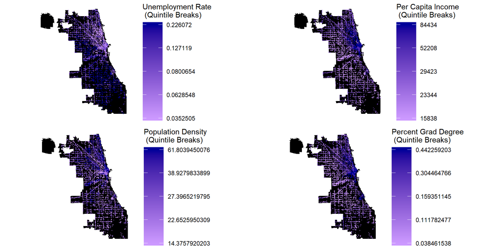

As for the 311 calls such as sanitation complaints and rodent baiting requests, because they are also based on date and time, which means the conditions in 2015 could be quite different from 2016, we divide the inspection samples into year 2015 and 2016 and calculate each inspection case’s distance to nearest 10 requests in 2015 and 2016 respectively.

FIrst divide the sample into two.

```r
rec2016 <- inspection1516_demo %>%
  filter(year(Data2) == "2016") %>%
  na.omit()

rec2015 <- inspection1516_demo %>%
  filter(year(Data2) == "2015") %>%
  na.omit()

rec2015.xy <-
  rec2015 %>%
  cbind(.,st_coordinates(rec2015))  %>%
  st_set_geometry(NULL) %>%
  dplyr::select(X,Y) %>%
  as.matrix()

rec2016.xy <-
  rec2016 %>%
  cbind(.,st_coordinates(rec2016))  %>%
  st_set_geometry(NULL) %>%
  dplyr::select(X,Y) %>%
  as.matrix()
```

Then pull out the data of sanitaion complaints in 2015 and 2016 respectively.

```r
sanitationComplaints <-
  read.socrata("https://data.cityofchicago.org/Service-Requests/311-Service-Requests-Sanitation-Code-Complaints/me59-5fac") %>%
  mutate(year = substr(Creation.Date,1,4))

sani2015 <-
  sanitationComplaints %>%
  filter(year == "2015") %>%
  dplyr::select(Latitude,Longitude, Y = Latitude, X = Longitude) %>%
  na.omit() %>%
  st_as_sf(coords = c("X", "Y"), crs = 4326, agr = "constant") %>%
  st_sf() %>%
  st_transform(st_crs(parks))

sani2016 <-
  sanitationComplaints %>%
  filter(year == "2016") %>%
  dplyr::select(Latitude,Longitude, Y = Latitude, X = Longitude) %>%
  na.omit() %>%
  st_as_sf(coords = c("X", "Y"), crs = 4326, agr = "constant") %>%
  st_sf() %>%
  st_transform(st_crs(parks))
```

Then we use the same function we defined before to get the nearest neighbor distance.

```r
sani2015.xy <-
  sani2015 %>%
  cbind(.,st_coordinates(st_centroid(sani2015)))  %>%
  st_set_geometry(NULL) %>%
  dplyr::select(X,Y) %>%
  as.matrix()

sani2016.xy <-
  sani2016 %>%
  cbind(.,st_coordinates(st_centroid(sani2016)))  %>%
  st_set_geometry(NULL) %>%
  dplyr::select(X,Y) %>%
  as.matrix()

distSani2015 <- as.data.frame(nn_function(rec2015.xy,sani2015.xy,10))

rec2015 <-
  cbind(as.data.frame(rec2015),distSani2015) %>%
  st_sf() %>%
  rename(Sanidis=pointDistance)

distSani2016 <- as.data.frame(nn_function(rec2016.xy,sani2016.xy,10))

rec2016 <-
  cbind(as.data.frame(rec2016),distSani2016) %>%
  st_sf() %>%
  rename(Sanidis=pointDistance)
```

We can create a map to compare the distribution of distance to sanitation complaints in 2015 and 2016. They turn out quite similar. The area in lighter color should be where sanitation conditions are worse, as the average distance to reported spots is smaller.

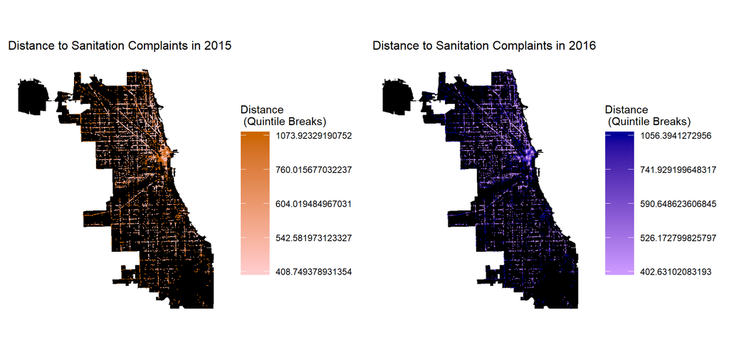

```r
sc1<-ggplot() +
  geom_sf(data=st_union(citymap), aes(), fill='black', colour=NA) +
  geom_point(data=rec2015,
             aes(x=as.numeric(Longitude),y=as.numeric(Latitude), color=ntile(rec2015$Sanidis,5)), size=0.1) +
  scale_color_gradient(low = "#ffcccc", high = "#cc6600", space = "Lab",
                       labels=as.character(quantile(rec2015$Sanidis,
                                                    c(.2,.4,.5,.7,.9),na.rm=T)),
                       name="Distance\n (Quintile Breaks)") +
  labs(title = "Distance to Sanitation Complaints in 2015") +
  mapTheme() +
  theme(legend.position = "right", legend.key.size = unit(1,"cm"), legend.key = element_rect(fill = "white", colour = "white"),plot.title = element_text(size = 12))


sc2<-ggplot() +
  geom_sf(data=st_union(citymap), aes(), fill='black', colour=NA) +
  geom_point(data=rec2016,
             aes(x=as.numeric(Longitude),y=as.numeric(Latitude), color=ntile(rec2016$Sanidis,5)), size=0.1) +
  scale_color_gradient(low = "#cc99ff", high = "#000099", space = "Lab",
                       labels=as.character(quantile(rec2016$Sanidis,
                                                    c(.2,.4,.5,.7,.9),na.rm=T)),
                       name="Distance\n (Quintile Breaks)") +
  labs(title = "Distance to Sanitation Complaints in 2016") +
  mapTheme() +
  theme(legend.position = "right", legend.key.size = unit(1,"cm"), legend.key = element_rect(fill = "white", colour = "white"),plot.title = element_text(size = 12))


ggarrange(sc1,sc2, ncol = 2, nrow = 1)
```

Similarly we calculate the nearest distance of each inspection case to rodent baiting requests.

```r
rodentBaiting <-
  read.socrata("https://data.cityofchicago.org/Service-Requests/311-Service-Requests-Rodent-Baiting-No-Duplicates/uqhs-j723") %>%
  mutate(year = substr(Creation.Date,1,4))

rodent2015 <-
  rodentBaiting %>%
  filter(year == "2015") %>%
  dplyr::select(Latitude,Longitude, Y = Latitude, X = Longitude) %>%
  na.omit() %>%
  st_as_sf(coords = c("X", "Y"), crs = 4326, agr = "constant") %>%
  st_sf() %>%
  st_transform(st_crs(parks))

rodent2016 <-
  rodentBaiting %>%
  filter(year == "2016") %>%
  dplyr::select(Latitude,Longitude, Y = Latitude, X = Longitude) %>%
  na.omit() %>%
  st_as_sf(coords = c("X", "Y"), crs = 4326, agr = "constant") %>%
  st_sf() %>%
  st_transform(st_crs(parks))

rodent2015.xy <-
  rodent2015 %>%
  cbind(.,st_coordinates(st_centroid(rodent2015)))  %>%
  st_set_geometry(NULL) %>%
  dplyr::select(X,Y) %>%
  as.matrix()

rodent2016.xy <-
  rodent2016 %>%
  cbind(.,st_coordinates(st_centroid(rodent2016)))  %>%
  st_set_geometry(NULL) %>%
  dplyr::select(X,Y) %>%
  as.matrix()

distRodent2015 <- as.data.frame(nn_function(rec2015.xy,rodent2015.xy,10))

rec2015 <-
  cbind(as.data.frame(rec2015),distRodent2015) %>%
  st_sf() %>%
  rename(Rodentdis=pointDistance)

distRodent2016 <- as.data.frame(nn_function(rec2016.xy,rodent2016.xy,10))

rec2016 <-
  cbind(as.data.frame(rec2016),distRodent2016) %>%
  st_sf() %>%
  rename(Rodentdis=pointDistance)
```

## 2.4. Comparison between establishments with and without fail records

```r
Fail_by_est <-
  rec2015 %>%
  na.omit %>%
  group_by(license_number) %>%
  summarise(inspectioncount = n(), failEver = as.factor(max(Res)),
            Rodent = max(Rodentdis), Sanitation = max(Sanidis),
            Landmark =max(Landmarkdis), pop_den = max(pop_den),
            Pct_Grad = max(Pct_Grad), Days_in_busi = as.numeric(max(Days_in_busi)),
            PctImmigra = max(PctImmigra), MedAge = max(MedAge),
            PctOver65 = max(PctOver65), PerCapInc = max(PerCapInc),
            Pov_R = max(Pov_R))


Compare_failEver <-
  Fail_by_est %>%
  na.omit %>%
  group_by(failEver) %>%
  summarise(Days_in_busi = mean(Days_in_busi), Rodent = mean(Rodent),
            Sanitation = mean(Sanitation), Landmark =mean(Landmark),
            pop_den = mean(pop_den), MedAge = mean(MedAge),
            PerCapInc = mean(PerCapInc),
            PctImmigra = mean(PctImmigra),Pov_R = mean(Pov_R),
            PctOver65 = mean(PctOver65))
```

```r
Compare_failEver <- as.data.frame(Compare_failEver)
Compare_failEver <- Compare_failEver[,c(1:11)]

Compare_failEver %>%
  kable(align = "c") %>%
  kable_styling(bootstrap_options = c("striped", "hover", "condensed"),full_width = T)
```

| failEver | Days_in_busi | Rodent | Sanitation | Landmark | pop_den | MedAge | PerCapInc | PctImmigra | Pov_R | PctOver65 |
| --- | --- | --- | --- | --- | --- | --- | --- | --- | --- | --- |
| 0 | 2087.471 | 608.3542 | 691.6733 | 5246.542 | 33.70701 | 34.31498 | 40055.50 | 0.8621243 | 0.1504925 | 0.1008455 |
| 1 | 2227.865 | 607.7457 | 679.2638 | 4506.026 | 34.85080 | 34.48007 | 42440.78 | 0.8519818 | 0.1469739 | 0.1006793 |

# 3. Methods

The method we adopted here is a Logistic Regression Model, and we will go through four steps in the following sections to ensure our model is effective and robust.

The first step is in-sample prediction. Initially we have got over 30 independent variables and we decided to narrow down to 13 without worsening our model¡¯s performance. Then we run the model using the whole inspection dataset in 2015 to get a general idea of how it performs.

One important goal of predictive modeling is generalizability, therefore, we would want to know whether our model is able to predict well for data it has no seen yet. In the second step, we train our model with 2015 data and test it on 2016 data to see its generalizability across time. Since we also want to see whether our model is generalizable across different establishment types, in the third step, we train our model on all the restaurants and test it on all the other types of facilities. Last but not least, we assess how our model performs spatially by conducting a Moran¡¯s I test.

# 4. Results

Here is the final model we produced. According the statistical summary, the Fail_rate and Failcount are the most powerful and significant predictors in our model.

```r
mylogit <- glm(Res ~  Days_in_busi +  fail_rate + failcount +
                  Sanidis + Rodentdis + Parkdis  + Landmarkdis +
                  MaxT + pop_den + Pct_Grad + PerCapInc + Unemp_R + PctImmigra,
                data = rec2015_final, family = "binomial"(link="logit"))

summary(mylogit)
```

```
##
## Call:
## glm(formula = Res ~ Days_in_busi + fail_rate + failcount + Sanidis +
##     Rodentdis + Parkdis + Landmarkdis + MaxT + pop_den + Pct_Grad +
##     PerCapInc + Unemp_R + PctImmigra, family = binomial(link = "logit"),
##     data = rec2015_final)
##
## Deviance Residuals:
##     Min       1Q   Median       3Q      Max
## -2.2251  -0.1750  -0.1726   0.1687   2.5121
##
## Coefficients:
##                     Estimate      Std. Error z value             Pr(>|z|)
## (Intercept)  -4.169428340228  0.186473296198 -22.359 < 0.0000000000000002
## Days_in_busi  0.000003349733  0.000014931759   0.224                0.822
## fail_rate     8.740087202841  0.196262341011  44.533 < 0.0000000000000002
## failcount    -0.151639181407  0.037490121788  -4.045            0.0000524
## Sanidis      -0.000011378227  0.000090326762  -0.126                0.900
## Rodentdis    -0.000012422295  0.000083883893  -0.148                0.882
## Parkdis       0.000007782011  0.000037647212   0.207                0.836
## Landmarkdis  -0.000004358502  0.000010021295  -0.435                0.664
## MaxT         -0.000110674961  0.001228579250  -0.090                0.928
## pop_den       0.000128603221  0.000968262764   0.133                0.894
## Pct_Grad     -0.061829877599  0.278964979400  -0.222                0.825
## PerCapInc     0.000000005072  0.000001318627   0.004                0.997
## Unemp_R       0.000767034542  0.318701307047   0.002                0.998
## PctImmigra    0.000138900585  0.099326921110   0.001                0.999
##
## (Intercept)  ***
## Days_in_busi
## fail_rate    ***
## failcount    ***
## Sanidis
## Rodentdis
## Parkdis
## Landmarkdis
## MaxT
## pop_den
## Pct_Grad
## PerCapInc
## Unemp_R
## PctImmigra
## ---
## Signif. codes:  0 '***' 0.001 '**' 0.01 '*' 0.05 '.' 0.1 ' ' 1
##
## (Dispersion parameter for binomial family taken to be 1)
##
##     Null deviance: 17901  on 14032  degrees of freedom
## Residual deviance:  9132  on 14019  degrees of freedom
## AIC: 9160
##
## Number of Fisher Scoring iterations: 6
```

## 4.1. In-Sample Prediction Results & Validation on 2016 Outcomes

The separate results of predictions on 2015 and 2016 data are shown as follows. To illustrate the accuracy of our model, we plot the ROC curves and calculate the Area Under the Curve values. Each point on the curve falls above the straight line, indicating that we are making more correctness than mistakes. The AUC value means the probability that a randomly selected positive example is ranked higher than a randomly selected negative example.

```r
trainingProbs <- data.frame(Class = rec2015_final$Res,
                            Probs = mylogit$fitted.values)

testingProbs <- data.frame(Class = rec2016_final$Res,
                           Probs = predict(mylogit, rec2016_final, type="response"))

rec2016_final$Probs <- predict(mylogit, rec2016_final, type="response")
rec2015_final$Probs <- mylogit$fitted.values

AIC(mylogit)
```

```
## [1] 9160.044
```

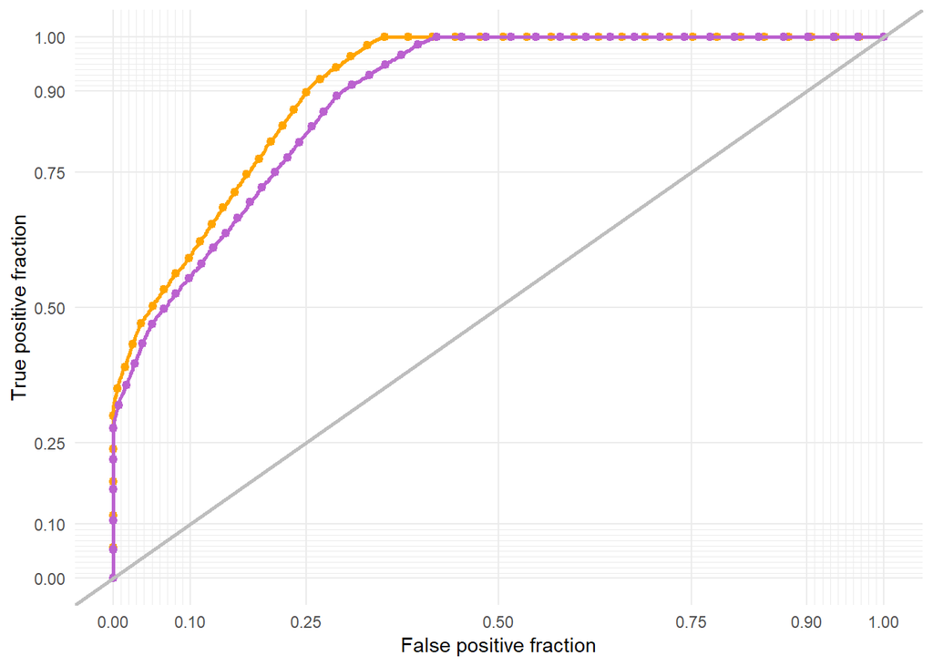

```r
ggplot() +
  geom_roc(data=trainingProbs, aes(d = Class, m = Probs),
           n.cuts = 50, labels = FALSE, colour = "orange") +
  geom_roc(data=testingProbs, aes(d = Class, m = Probs),
           n.cuts = 50, labels = FALSE, colour = "#bb61cf") +
  style_roc(theme = theme_grey) +
  geom_abline(slope = 1, intercept = 0, size = 1, color = 'grey') +
  theme_minimal()
```

With an AUC value of 0.9064, our model can properly predict 90.64% of whether a food establishment will fail an inspection or not in 2015, which is far better than chance. For the 2016 data, the model trained using 2015 data produces a similar ROC curve and a slightly lower AUC value of 0.8862. This means that our model predicts slightly better for inspection results in 2015 than those in 2016, to an acceptable degree.

```r
auc(trainingProbs$Class, trainingProbs$Probs)
```

```
## Area under the curve: 0.9064
```

```r
auc(testingProbs$Class, testingProbs$Probs)
```

```
## Area under the curve: 0.8862
```

To further compare the prediction results, we also plot the confusion matrix for 2015 and 2016. The confusion matrix illustrates the percentage of true and false prediction on whether an establishment will fail an inspection. According the following plot, the proportion of true predictions is much larger than that of false ones. In addition, the results of both true and false predictions for 2015 and 2016 are close to each other. Hence, our model is generalizable across time.

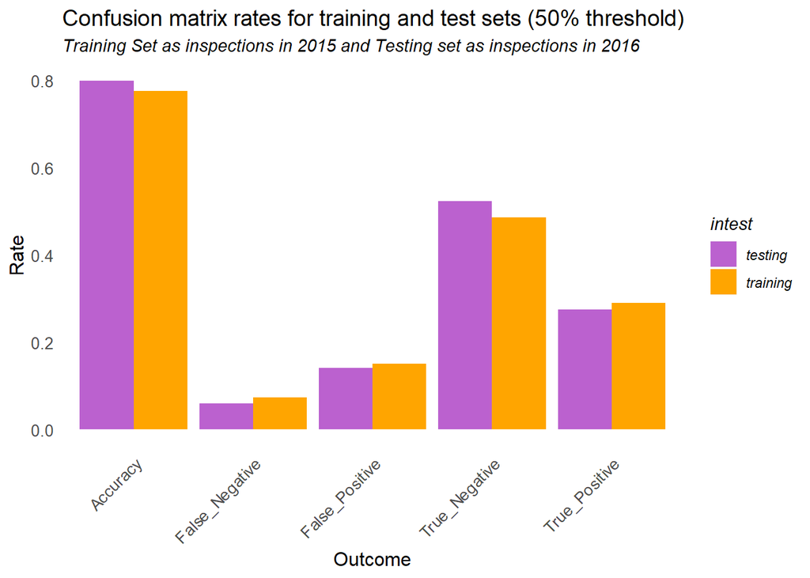

```r
rec2015_final <-
  rec2015_final %>%
  mutate(intest = "testing")

rec2016_final <-
  rec2016_final %>%
  mutate(intest = "training")

traintest <- rbind(as.data.frame(rec2015_final), as.data.frame(rec2016_final))
traintest$Prob_res = ifelse(traintest$Probs > .5 ,1,0)

Con_mat <-
  traintest %>%
  group_by(intest) %>%
  count(Prob_res,Res) %>%
  summarise(sum_trueNeg = sum(n[Prob_res==0 & Res==0]),
            sum_truePos = sum(n[Prob_res==1 & Res==1]),
            sum_falseNeg = sum(n[Prob_res==0 & Res==1]),
            sum_falsePos = sum(n[Prob_res==1 & Res==0]),
            total=sum(n)) %>%
  mutate(True_Positive = sum_truePos / total,
         True_Negative = sum_trueNeg / total,
         False_Negative = sum_falseNeg / total,
         False_Positive = sum_falsePos / total,
         Accuracy = (sum_truePos + sum_trueNeg) / total) %>%
  dplyr::select(intest, True_Positive, True_Negative, False_Negative, False_Positive,Accuracy) %>%
  gather(key,value,True_Positive:Accuracy) %>%
  ggplot(.,aes(key,value,fill=intest)) +
  geom_bar(aes(fill=intest),position="dodge",stat="identity") +
  scale_fill_manual(values = palette_2_colors) +
  labs(title="Confusion matrix rates for training and test sets (50% threshold)",
       subtitle = "Training Set as inspections in 2015 and Testing set as inspections in 2016",
       x="Outcome",y="Rate") +
  theme(axis.text.x = element_text(angle = 45, hjust = 1)) +
  plotTheme()

Con_mat
```

## 4.2. Validation on Different Establishment Types

Next, we want to examine whether our model is generalizable across different establishment types. We train our model using the 2016 inspection data of all restaurants, and then test it on all other establishment types.

```r
training1 <- rec2016_final %>%
  filter(establishment_type == "Restaurant")

testing1 <- rec2016_final %>%
  filter(establishment_type != "Restaurant")

mylogit1 <- glm(Res ~  Days_in_busi +  fail_rate + failcount +
                  Sanidis + Rodentdis + Parkdis  + Landmarkdis +
                  MaxT + pop_den + Pct_Grad + PerCapInc + Unemp_R + PctImmigra,
                data = training1, family = "binomial"(link="logit"))

summary(mylogit1)

trainingProbs1 <- data.frame(Class = training1$Res,
                            Probs = mylogit1$fitted.values)

testingProbs1 <- data.frame(Class = testing1$Res,
                            Probs = predict(mylogit1, testing1, type="response"))

testing1$Probs <- predict(mylogit1, testing1, type="response")
training1$Probs <- mylogit1$fitted.values
```

With an AUC value of 0.8822, our model can correctly predict 88.22% of whether a restaurant will fail an inspection. For other establishment types, the AUC value is slightly higher but close, which is 0.8974. Therefore, our model is generalizable across establishment types.

```r
auc(trainingProbs1$Class, trainingProbs1$Probs)
```

```
## Area under the curve: 0.8821
```

```r
auc(testingProbs1$Class, testingProbs1$Probs)
```

```
## Area under the curve: 0.8974
```

According the similar ROC curves and confusion matrix for prediction on restaurant and other types, we can draw the same conclusion.

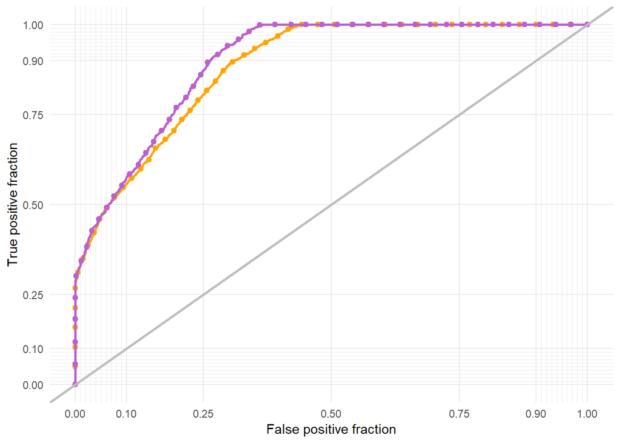

```r
ggplot() +
  geom_roc(data=trainingProbs1, aes(d = Class, m = Probs),
           n.cuts = 50, labels = FALSE, colour = "orange") +
  geom_roc(data=testingProbs1, aes(d = Class, m = Probs),
           n.cuts = 50, labels = FALSE, colour = "#bb61cf") +
  style_roc(theme = theme_grey) +
  geom_abline(slope = 1, intercept = 0, size = 1, color = 'grey') +
  theme_minimal()
```

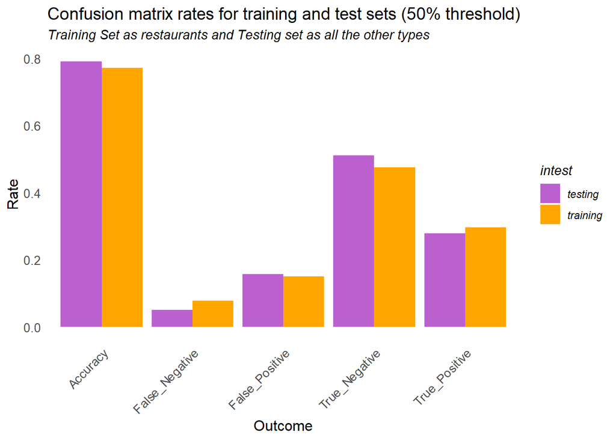

```r
testing1 <-
  testing1 %>%
  mutate(intest = "testing")

training1 <-
  training1 %>%
  mutate(intest = "training")

traintest1 <- rbind(as.data.frame(testing1), as.data.frame(training1))

traintest1$Prob_res = ifelse(traintest1$Probs > .5 ,1,0)

head(traintest1)

con_mat2 <-
  traintest1 %>%
  group_by(intest) %>%
  count(Prob_res,Res) %>%
  summarise(sum_trueNeg = sum(n[Prob_res==0 & Res==0]),
            sum_truePos = sum(n[Prob_res==1 & Res==1]),
            sum_falseNeg = sum(n[Prob_res==0 & Res==1]),
            sum_falsePos = sum(n[Prob_res==1 & Res==0]),
            total=sum(n)) %>%
  mutate(True_Positive = sum_truePos / total,
         True_Negative = sum_trueNeg / total,
         False_Negative = sum_falseNeg / total,
         False_Positive = sum_falsePos / total,
         Accuracy = (sum_truePos + sum_trueNeg) / total) %>%
  dplyr::select(intest, True_Positive, True_Negative, False_Negative, False_Positive,Accuracy) %>%
  gather(key,value,True_Positive:Accuracy) %>%
  ggplot(.,aes(key,value,fill=intest)) +
  geom_bar(aes(fill=intest),position="dodge",stat="identity") +
  scale_fill_manual(values = palette_2_colors) +
  labs(title="Confusion matrix rates for training and test sets (50% threshold)",
       subtitle = "Training Set as restaurants and Testing set as all the other types",
       x="Outcome",y="Rate") +
  theme(axis.text.x = element_text(angle = 45, hjust = 1)) +
  plotTheme()

con_mat2
```

## 4.3. Generalizability across space

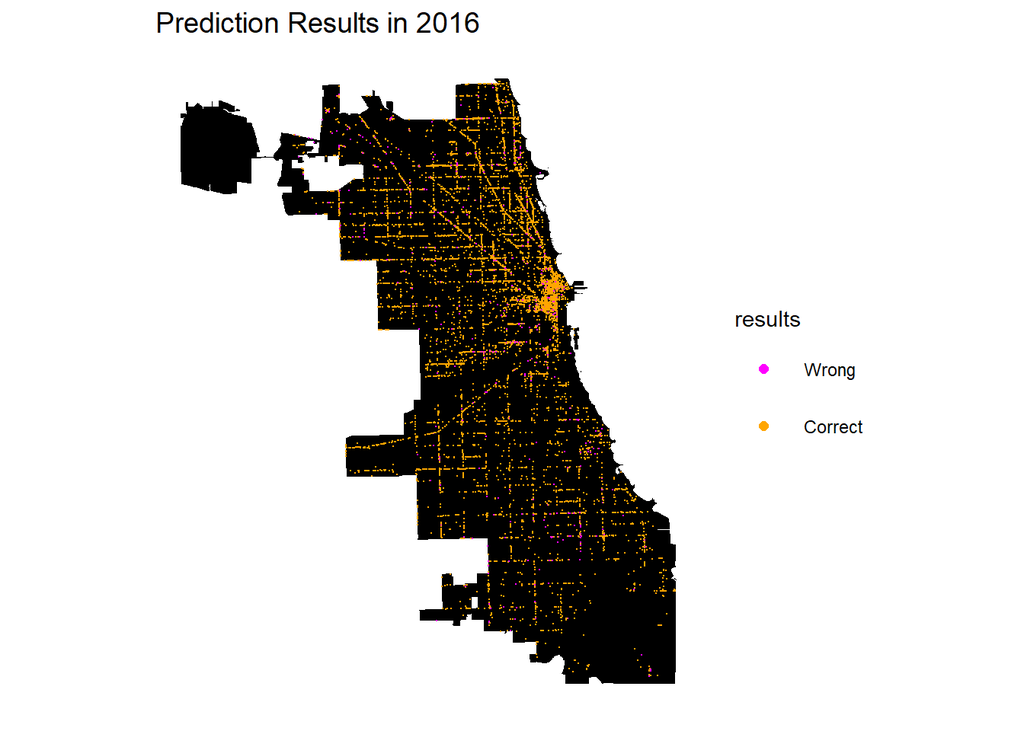

```r
traintest$correct<-0
traintest$correct[which(traintest$Prob_res==0 & traintest$Res==0 | traintest$Prob_res==1 & traintest$Res==1)] = 1
testset <- traintest[ traintest$intest == "testing", ]

ggplot() +
  geom_sf(data=st_union(citymap), aes(), fill='black', colour=NA) +
  geom_point(data=testset,
             aes(x=Longitude,y=Latitude, color=as.factor(testset$correct)), size=0.1) +
  scale_color_manual(values=c("#ff00ff", "orange"), name = "results",
                     labels=c("Wrong","Correct")) +
  labs(title = "Prediction Results in 2016") +
  mapTheme() +
  guides(colour = guide_legend(override.aes = list(size=2))) +
  theme(legend.position = "right", legend.key.size = unit(1,"cm"), legend.key = element_rect(fill = "white", colour = "white"))
```

```r
coords <- cbind(testset$Longitude, testset$Latitude)
spatialWeights <- knn2nb(knearneigh(coords, 4))
moran.test(testset$correct, nb2listw(spatialWeights, style="W"))
```

```
##
##  Moran I test under randomisation
##
## data:  testset$correct
## weights: nb2listw(spatialWeights, style = "W")
##
## Moran I statistic standard deviate = -13.755, p-value = 1
## alternative hypothesis: greater
## sample estimates:
## Moran I statistic       Expectation          Variance
##    -0.07567907343    -0.00007126568     0.00003021572
```

# 5. Discussion & Limitation

Generally speaking, we believe our model is an effective one, because it¡¯s both accurate and generalizable. The model could correctly predict 90.65 % of whether a food establishment will fail an inspection for 2015, which is far better than chance.

Regarding generalizability, we conduct two different validations to test whether our model can perform well. First, we train our model using 2015 data and test it using 2016 data. According to similar ROC curves and AUC values, our model is able to predict almost equally well for the two time periods. The confusion matrix of the training and testing set further indicates the similar true and false prediction results on whether an establishment will fail an inspection in 2015 and 2016. Therefore, our model is generalizable across time.

Next, we train our model using restaurant data and test it with all other establishment types to see whether it is generalizable across different types. Our model produces similar ROC curves and AUC values for the training and testing set, indicating the close predicting power for different establishment types. The confusion matrix suggests similar true and false prediction results on whether an establishment will fail an inspection or not and enables us to draw the conclusion that our model performs equally well across establishment types.

However, one limitation of our model is that it is overfitted due to one very significant predictor, the fail rate of an establishment in the past inspections. This is probably because the inspection result is pretty likely to be the same with previous ones. To improve our model, we will separate the internal characteristics of food establishments and the external ones such as the demographic characteristics of the block group which an establishment is located in to develop two different models. Then we will use the two prediction results produced by the two separate models as predictors to build a new model to mitigate the bias on prediction results brought by the extremely powerful predictor.

Besides, if we can gather more detailed information of each food establishment, such as the area of store, numbers of employees, food process devices, etc., and include it in our model, it will be helpful to make more accurate predictions.

# 6. Conclusion

We believe our model is useful for future food inspection result prediction and can be used to help eaters make more deliberative dining choice, not only because it is able to explain the majority of inspection results, but also its generalizability across time, establishment type and space. However, it does not mean there is no room for improvement. As previously mentioned, we should try to sperate internal and external characteristics of establishments to mitigate the bias brought by one extremely significant predictor and thus better the model¡¯s performance. In addition, it would be beneficial for us to get more exact information of each food establishment to increase the predicting power of our model.